# Practica1DEF

# Carga y limpieza de datos

lo primero que hay que hacer es un trabajo previo de visualizacion de los datos, para ver que tenemos, y a continuacion, proceder a la limpieza de aquellas variables que sean irrelevantes para nuestro caso de estudio.

```r
fondos=read.csv2("C:/Users/Manuel/Desktop/CUNEF/Prediccion/Tarea1/Fondos.csv")
View(fondos)
```

Sustituimos los NA values por los valores mas cercanos.

```r
library(rminer)
library(caret)
fondos2=imputation("hotdeck",fondos)
View(fondos2)

#por que me da error?
```

2ºElimino variables que a simple vista se que no me van a ayudar a explicar la rentabilidad de los fondos, por su contenido. Como queremos explicar la rentabilidad en 1 año, de las variables de rentabilidad nos quedaremos con rentabilidad a 3 meses, 6 meses, 1 año, 3 años y 5 años.

```r
fondos2 <- fondos2[ ,!colnames(fondos2)=="ImportFile_CustomDelayToBuy"]
fondos2 <- fondos2[ ,!colnames(fondos2)=="ImportFile_CustomBuyFee2"]
fondos2 <- fondos2[ ,!colnames(fondos2)=="X1_Day_Return"]
fondos2 <- fondos2[ ,!colnames(fondos2)=="X1_Week_Return"]
fondos2 <- fondos2[ ,!colnames(fondos2)=="rent_1_mes"]
fondos2 <- fondos2[ ,!colnames(fondos2)=="rent_10_anios"]
fondos2 <- fondos2[ ,!colnames(fondos2)=="Dias_depl_reemb"]
fondos2 <- fondos2[ ,!colnames(fondos2)=="Com_Suscripcion"]
fondos2 <- fondos2[ ,!colnames(fondos2)=="ISIN"]
```

3ºCompruebo que se aplican los cambios.

```r
View(fondos2)
```

# Regresión 1

```r
regresion1=lm(rent_1~1+rent_en_el_anio+Estilo_inversion_RV+rent_en_el_anio:rent_3_anios+Volatilidad_3+Morningstar_Rating,data=fondos2)
summary(regresion1)
```

```
##
## Call:
## lm(formula = rent_1 ~ 1 + rent_en_el_anio + Estilo_inversion_RV +
##     rent_en_el_anio:rent_3_anios + Volatilidad_3 + Morningstar_Rating,
##     data = fondos2)
##
## Residuals:
##     Min      1Q  Median      3Q     Max
## -9.5563 -0.5154  0.0328  0.4865  5.2641
##
## Coefficients:
##                               Estimate Std. Error t value Pr(>|t|)
## (Intercept)                  -1.182446   0.245231  -4.822 1.90e-06 ***
## rent_en_el_anio               0.808055   0.014639  55.200  < 2e-16 ***
## Estilo_inversion_RV           0.129336   0.029335   4.409 1.28e-05 ***
## Volatilidad_3                -0.233137   0.013113 -17.779  < 2e-16 ***
## Morningstar_Rating            0.255681   0.063352   4.036 6.30e-05 ***
## rent_en_el_anio:rent_3_anios  0.017796   0.003097   5.746 1.60e-08 ***
## ---
## Signif. codes:  0 '***' 0.001 '**' 0.01 '*' 0.05 '.' 0.1 ' ' 1
##
## Residual standard error: 1.287 on 494 degrees of freedom
## Multiple R-squared:  0.8865, Adjusted R-squared:  0.8854
## F-statistic: 771.9 on 5 and 494 DF,  p-value: < 2.2e-16
```

como podemos observar, todas las variables son significativas y el R-cuadrado apenas difiere de R-cuadrado ajustado.Este es el resultado de eliminar variables menos significativas como Patrimonio. A pesar de haber sustituido los NA values por los valores mas cercanos, conviene no utilizar variables que previamente tenían muchísimos valores nulos (rentabilidad a 10 años, por ejemplo).

## NOrmalidad:QQplot

Un gráfico Cuantil-Cuantil permite observar cuan cerca está la distribución de un conjunto de datos a alguna distribución ideal o comparar la distribución de dos conjuntos de datos. En este caso queremos ver si sigue la normal.

```r
library(car)
```

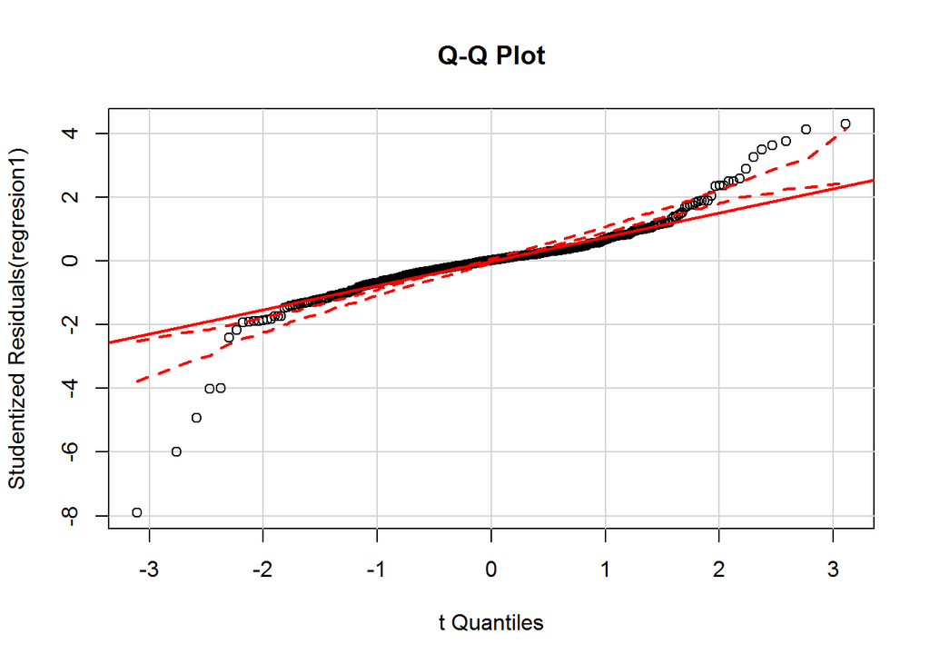

```r
qqPlot(regresion1, labels=row.names(fondos2), id.method="identify",
       simulate=TRUE, main="Q-Q Plot")
```

Como podemos observar, parece que nuestra muestra presenta mas valores extremos de los que se esperaría de una distribución normal.

## Histograma + densidad + normal + rugs

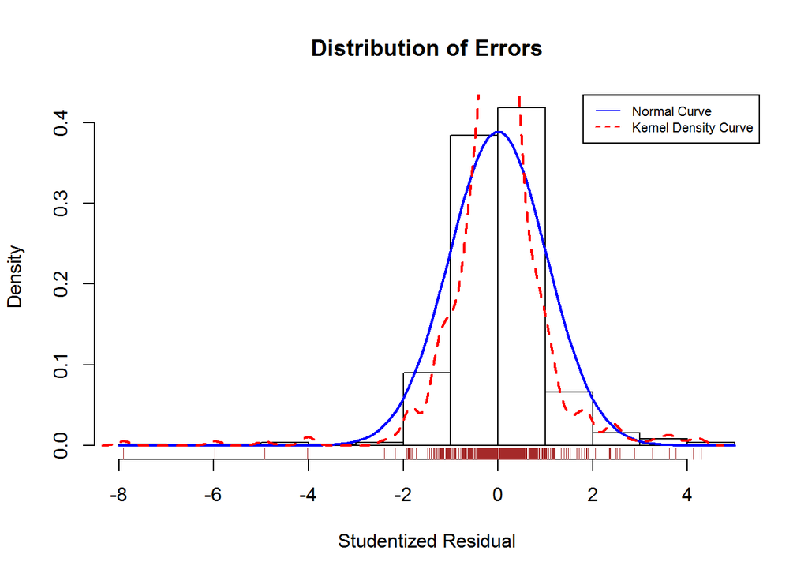

```r
residplot <- function(fit, nbreaks=10) {
  z <- rstudent(fit)
  hist(z, breaks=nbreaks, freq=FALSE,
       xlab="Studentized Residual",
       main="Distribution of Errors")
  rug(jitter(z), col="brown")
  curve(dnorm(x, mean=mean(z), sd=sd(z)),
        add=TRUE, col="blue", lwd=2)
  lines(density(z)$x, density(z)$y,
        col="red", lwd=2, lty=2)
  legend("topright",
         legend = c( "Normal Curve", "Kernel Density Curve"),
         lty=1:2, col=c("blue","red"), cex=.7)
}

residplot(regresion1)
```

Como vemos, el gráfico no se parece a la normal. El pico es mucho mas pronunciado, lo que deja entrever que la curva es leptocúrtica (gran curtosis).

## Jarque - Bera

el contraste de normalidad de Jarque-Bera nos da como hipótesis nula, que la distribución es normal:

```r
vResid<-resid(regresion1)
library(fBasics)
library(akima)
jbTest(vResid)
```

```
##
## Title:
##  Jarque - Bera Normality Test
##
## Test Results:
##   PARAMETER:
##     Sample Size: 500
##   STATISTIC:
##     LM: 2369.743
##     ALM: 2446.067
##   P VALUE:
##     Asymptotic: < 2.2e-16
##
## Description:
##  Fri Oct 27 00:44:24 2017 by user: Manuel
```

como el p-value es cero, se rechaza la hipótesis nula –> la distribución no es normal.

## Saphiro

Otra forma de comprobar si una distribucion ha sido generada por una normal es el test de Shapiro-Wilk:

```r
shapiro.test(vResid)
```

```
##
##  Shapiro-Wilk normality test
##
## data:  vResid
## W = 0.86641, p-value < 2.2e-16
```

Resultado equivalente al de Jarque BeraComo el p-value es cero, la distribucion NO ha sido generada por una distribución normal.

## LINEALIDAD - crPlots

En esta esta vamos a graficar los valores ajustados respecto a los predictores. Si no hay problemas de linealidad se obtendrá una recta sobre la que se representan los puntos.

Los gráficos representan sobre una linea verde la estimacion, y sobre una roja aquella a la que deberían aproximarse. No podemos obtener los gráficos puesto que hay variables asociadas entre si.

```r
#crPlots(regresion1)
```

## HOMOCEDASTICIDAD - ncvTest

Partimos de la hipótesis que tenemos homocedasticidad en nuestros errores.

Realizamos el test de Breusch-Pagan:

```r
ncvTest(regresion1)
```

```
## Non-constant Variance Score Test
## Variance formula: ~ fitted.values
## Chisquare = 60.3136    Df = 1     p = 8.088672e-15
```

## Validacion Global

A modo de resumen, podemos contrastar todas las hipótesis mediante el test de Peña

```r
library(gvlma)
gvmode1<-gvlma(regresion1)
gvmode1
```

```
##
## Call:
## lm(formula = rent_1 ~ 1 + rent_en_el_anio + Estilo_inversion_RV +
##     rent_en_el_anio:rent_3_anios + Volatilidad_3 + Morningstar_Rating,
##     data = fondos2)
##
## Coefficients:
##                  (Intercept)               rent_en_el_anio
##                      -1.1824                        0.8081
##          Estilo_inversion_RV                 Volatilidad_3
##                       0.1293                       -0.2331
##           Morningstar_Rating  rent_en_el_anio:rent_3_anios
##                       0.2557                        0.0178
##
##
## ASSESSMENT OF THE LINEAR MODEL ASSUMPTIONS
## USING THE GLOBAL TEST ON 4 DEGREES-OF-FREEDOM:
## Level of Significance =  0.05
##
## Call:
##  gvlma(x = regresion1)
##
##                       Value   p-value                   Decision
## Global Stat        2372.616 0.000e+00 Assumptions NOT satisfied!
## Skewness             62.573 2.554e-15 Assumptions NOT satisfied!
## Kurtosis           2307.170 0.000e+00 Assumptions NOT satisfied!
## Link Function         1.478 2.241e-01    Assumptions acceptable.
## Heteroscedasticity    1.396 2.374e-01    Assumptions acceptable.
```

## Multicolinealidad

Se define multicolinealidad como la correlación entre predictores, pudiendo causar problemas con los estimadores.

Para ver si existe multicolinealidad, utilizamos la función VIF (Factor de inflación de la varianza).

En los casos en los que la raíz cuadrada de VIF es mayor de 2, se considera que existen problemas de multicolinealidad.

```r
vif(regresion1)
```

```
##              rent_en_el_anio          Estilo_inversion_RV
##                     1.306996                     1.002248
##                Volatilidad_3           Morningstar_Rating
##                     1.173313                     1.028187
## rent_en_el_anio:rent_3_anios
##                     1.178422
```

```r
sqrt(vif(regresion1)) > 2
```

```
##              rent_en_el_anio          Estilo_inversion_RV
##                        FALSE                        FALSE
##                Volatilidad_3           Morningstar_Rating
##                        FALSE                        FALSE
## rent_en_el_anio:rent_3_anios
##                        FALSE
```

Como podemos observar, no tenemos multicolinealidad.

## Observaciones anómalas

Mediante el test de Boniferri identificamos los valores atípicos. Se analiza el mayor de los residuos, y si este no es atípico, se asume que no hay atípicos en la muestra.

```r
outlierTest(regresion1)
```

```
##      rstudent unadjusted p-value Bonferonni p
## 462 -7.904800         1.7699e-14   8.8494e-12
## 48  -5.980839         4.2680e-09   2.1340e-06
## 476 -4.932555         1.1114e-06   5.5570e-04
## 7    4.291966         2.1328e-05   1.0664e-02
## 173  4.126320         4.3272e-05   2.1636e-02
## 118 -4.024863         6.5974e-05   3.2987e-02
## 28  -3.999861         7.3100e-05   3.6550e-02
```

Existen distintos outliers en la muestra, 7 concretamente.

Determinacion de valores extremos (hat statistic): - p: numero de parametros estimados - n: tamaño de la muestra

Las bservaciones con valor 2 o 3 veces el valor de la media se consideran extremas

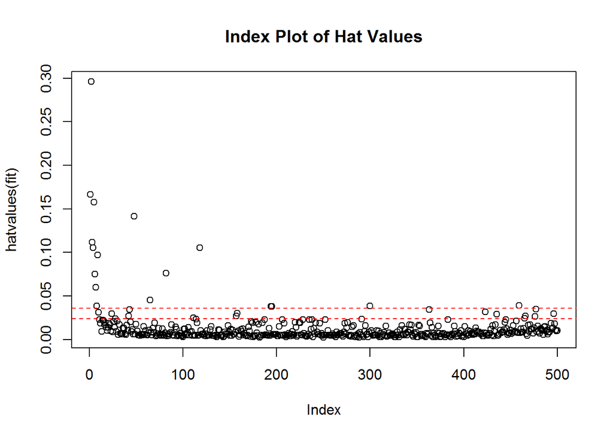

```
## integer(0)
```

```r
hat.plot <- function(fit) {
  p <- length(coefficients(fit))
  n <- length(fitted(fit))
  plot(hatvalues(fit), main="Index Plot of Hat Values")
  abline(h=c(2,3)*p/n, col="red", lty=2)
  identify(1:n, hatvalues(fit), names(hatvalues(fit)))
}
hat.plot(regresion1)
```

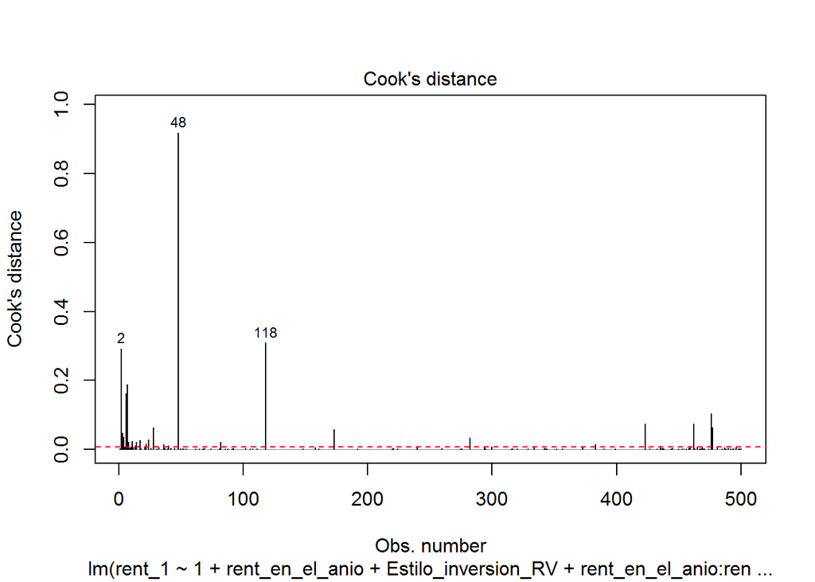

```r
cutoff <- 4/(nrow(fondos)-length(regresion1$coefficients)-2)
plot(regresion1, which=4, cook.levels=cutoff)
abline(h=cutoff, lty=2, col="red")
```

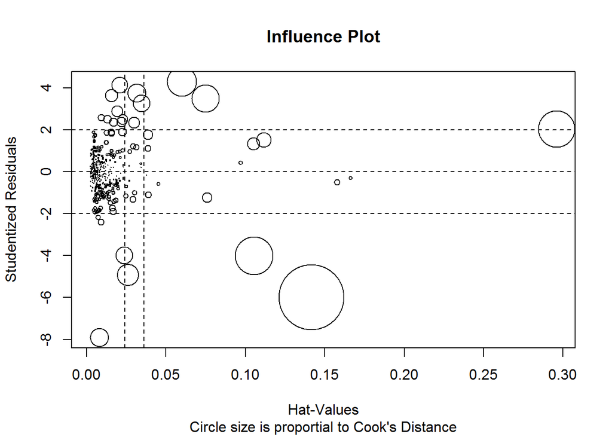

```r
influencePlot(regresion1, id.method="identify", main="Influence Plot",
              sub="Circle size is proportial to Cook's Distance" )
```

# Regresión 2

```r
regresion2=lm(rent_1~1+rent_en_el_anio+Volatilidad_3+Media_3+rent_en_el_anio:rent_5_anios+rent_en_el_anio:rent_3_anios,data=fondos2)
summary(regresion2)
```

```
##
## Call:
## lm(formula = rent_1 ~ 1 + rent_en_el_anio + Volatilidad_3 + Media_3 +
##     rent_en_el_anio:rent_5_anios + rent_en_el_anio:rent_3_anios,
##     data = fondos2)
##
## Residuals:
##     Min      1Q  Median      3Q     Max
## -9.7560 -0.4195  0.0955  0.3483  8.9539
##
## Coefficients:
##                               Estimate Std. Error t value Pr(>|t|)
## (Intercept)                  -0.161559   0.085950  -1.880   0.0607 .
## rent_en_el_anio               0.845910   0.014313  59.101  < 2e-16 ***
## Volatilidad_3                -0.319159   0.014777 -21.599  < 2e-16 ***
## Media_3                       2.665115   0.300864   8.858  < 2e-16 ***
## rent_en_el_anio:rent_5_anios -0.021297   0.005198  -4.097 4.89e-05 ***
## rent_en_el_anio:rent_3_anios  0.032936   0.007532   4.373 1.50e-05 ***
## ---
## Signif. codes:  0 '***' 0.001 '**' 0.01 '*' 0.05 '.' 0.1 ' ' 1
##
## Residual standard error: 1.218 on 494 degrees of freedom
## Multiple R-squared:  0.8983, Adjusted R-squared:  0.8973
## F-statistic: 872.7 on 5 and 494 DF,  p-value: < 2.2e-16
```

## NOrmalidad:QQplot

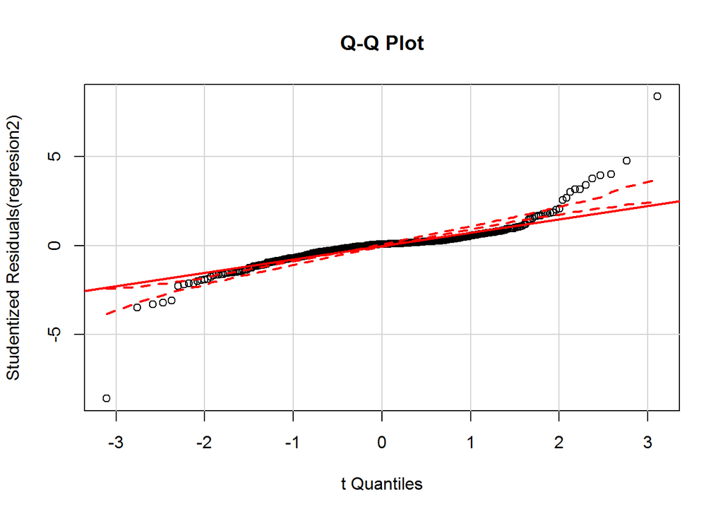

```r
library(car)
qqPlot(regresion2, labels=row.names(fondos2), id.method="identify",
       simulate=TRUE, main="Q-Q Plot")
```

Como podemos observar, en este caso se repite la sensación de que hay mas valores extremos de los que se esperaría de una distribución normal.

## Histograma + densidad + normal + rugs

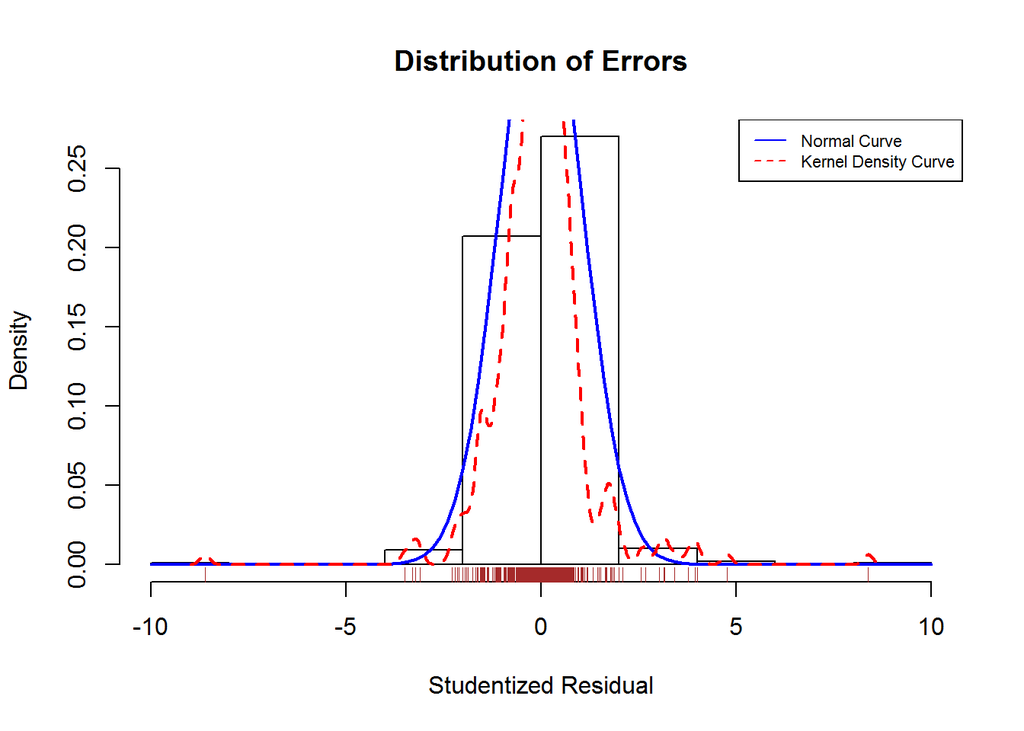

```r
residplot <- function(fit, nbreaks=10) {
  z <- rstudent(fit)
  hist(z, breaks=nbreaks, freq=FALSE,
       xlab="Studentized Residual",
       main="Distribution of Errors")
  rug(jitter(z), col="brown")
  curve(dnorm(x, mean=mean(z), sd=sd(z)),
        add=TRUE, col="blue", lwd=2)
  lines(density(z)$x, density(z)$y,
        col="red", lwd=2, lty=2)
  legend("topright",
         legend = c( "Normal Curve", "Kernel Density Curve"),
         lty=1:2, col=c("blue","red"), cex=.7)
}

residplot(regresion2)
```

El gráfico muestra claramente que la distribución no es normal y que existe gran curtosis.

## Jarque - Bera

```r
vResid<-resid(regresion2)
library(fBasics)
library(akima)
jbTest(vResid)
```

```
##
## Title:
##  Jarque - Bera Normality Test
##
## Test Results:
##   PARAMETER:
##     Sample Size: 500
##   STATISTIC:
##     LM: 5374.162
##     ALM: 5545.768
##   P VALUE:
##     Asymptotic: < 2.2e-16
##
## Description:
##  Fri Oct 27 00:44:55 2017 by user: Manuel
```

como el p-value es cero, se rechaza la hipótesis nula –> la distribución no es normal.

## Saphiro

```r
shapiro.test(vResid)
```

```
##
##  Shapiro-Wilk normality test
##
## data:  vResid
## W = 0.81666, p-value < 2.2e-16
```

Se corrobora el resultado anterior

## HOMOCEDASTICIDAD - ncvTest

```r
ncvTest(regresion2)
```

```
## Non-constant Variance Score Test
## Variance formula: ~ fitted.values
## Chisquare = 10.67368    Df = 1     p = 0.001086709
```

El modelo presenta heterocedasticidad.

## Validacion Global

```r
library(gvlma)
gvmode1<-gvlma(regresion2)
gvmode1
```

```
##
## Call:
## lm(formula = rent_1 ~ 1 + rent_en_el_anio + Volatilidad_3 + Media_3 +
##     rent_en_el_anio:rent_5_anios + rent_en_el_anio:rent_3_anios,
##     data = fondos2)
##
## Coefficients:
##                  (Intercept)               rent_en_el_anio
##                     -0.16156                       0.84591
##                Volatilidad_3                       Media_3
##                     -0.31916                       2.66511
## rent_en_el_anio:rent_5_anios  rent_en_el_anio:rent_3_anios
##                     -0.02130                       0.03294
##
##
## ASSESSMENT OF THE LINEAR MODEL ASSUMPTIONS
## USING THE GLOBAL TEST ON 4 DEGREES-OF-FREEDOM:
## Level of Significance =  0.05
##
## Call:
##  gvlma(x = regresion2)
##
##                       Value p-value                   Decision
## Global Stat        5382.415 0.00000 Assumptions NOT satisfied!
## Skewness              3.711 0.05407    Assumptions acceptable.
## Kurtosis           5370.452 0.00000 Assumptions NOT satisfied!
## Link Function         3.614 0.05729    Assumptions acceptable.
## Heteroscedasticity    4.638 0.03127 Assumptions NOT satisfied!
```

## Multicolinealidad

```r
vif(regresion2)
```

```
##              rent_en_el_anio                Volatilidad_3
##                     1.394060                     1.662379
##                      Media_3 rent_en_el_anio:rent_5_anios
##                     1.812806                     7.572408
## rent_en_el_anio:rent_3_anios
##                     7.777453
```

```r
sqrt(vif(regresion2)) > 2
```

```
##              rent_en_el_anio                Volatilidad_3
##                        FALSE                        FALSE
##                      Media_3 rent_en_el_anio:rent_5_anios
##                        FALSE                         TRUE
## rent_en_el_anio:rent_3_anios
##                         TRUE
```

El segundo modelo presenta colinealidad en dos de las variables

## Observaciones anómalas

```r
outlierTest(regresion2)
```

```
##      rstudent unadjusted p-value Bonferonni p
## 462 -8.610645         9.8393e-17   4.9196e-14
## 173  8.386969         5.2809e-16   2.6405e-13
## 6    4.770359         2.4259e-06   1.2129e-03
## 7    4.003519         7.2014e-05   3.6007e-02
## 11   3.942909         9.2156e-05   4.6078e-02
```

El modelo presenta 5 outliers

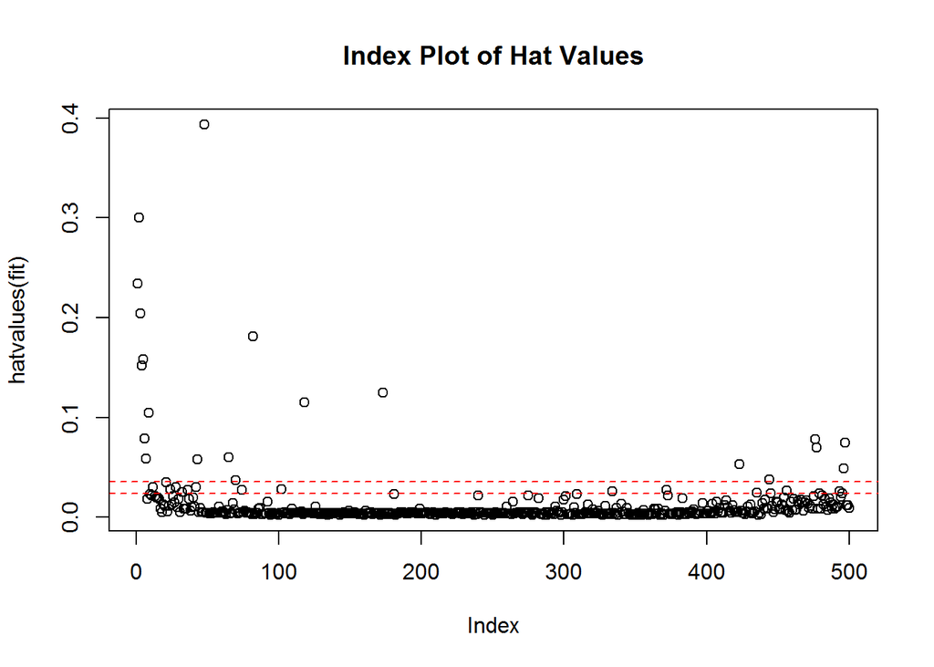

```
## integer(0)
```

```r
hat.plot <- function(fit) {
  p <- length(coefficients(fit))
  n <- length(fitted(fit))
  plot(hatvalues(fit), main="Index Plot of Hat Values")
  abline(h=c(2,3)*p/n, col="red", lty=2)
  identify(1:n, hatvalues(fit), names(hatvalues(fit)))
}
hat.plot(regresion2)
```

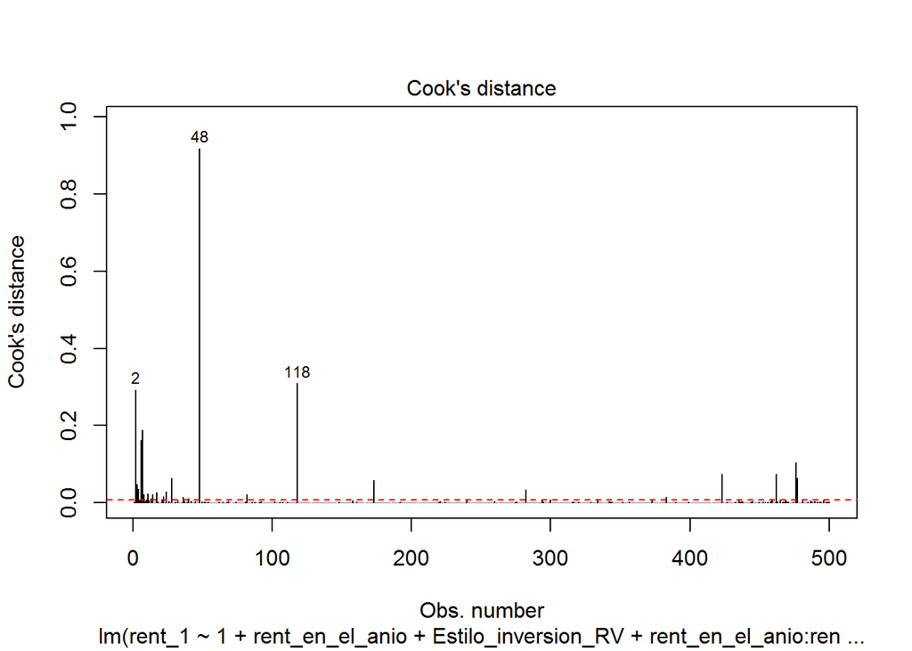

```r
cutoff <- 4/(nrow(fondos)-length(regresion1$coefficients)-2)
plot(regresion1, which=4, cook.levels=cutoff)
abline(h=cutoff, lty=2, col="red")
```

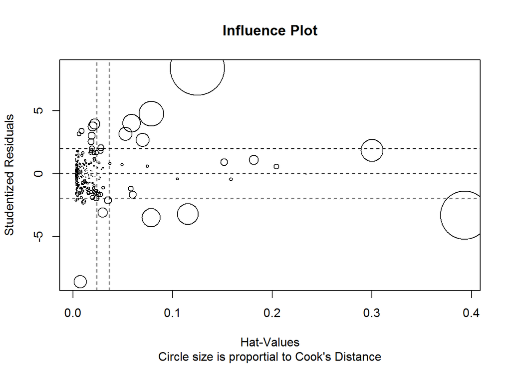

```r
influencePlot(regresion2, id.method="identify", main="Influence Plot",
              sub="Circle size is proportial to Cook's Distance" )
```

# SELECCION

### AIC

Elegimos el modelo que tenga menor AIC. El modelo 2 tiene menor coeficiente AIC

```r
AIC(regresion1,regresion2)
```

```
##            df      AIC
## regresion1  7 1679.250
## regresion2  7 1624.498
```

Elegimos el modelo que tenga menor BIC. El modelo 2 tiene menor coeficiente BIC

```r
BIC(regresion1,regresion2)
```

```
##            df      BIC
## regresion1  7 1708.753
## regresion2  7 1654.000
```

# CrossValidation

### Modelo 1

```r
library(ISLR)
set.seed(250)
numData=nrow(fondos2)
train=sample(numData ,numData/2)

regres.train =lm(rent_1~1+rent_en_el_anio+Estilo_inversion_RV+rent_en_el_anio:rent_3_anios+Volatilidad_3+Morningstar_Rating,data=fondos2,subset=train)

attach(fondos2)
mean((rent_1-predict(regres.train ,Auto))[-train ]^2)
```

```
## [1] 2.009733
```

### Modelo2

Este modelo proporciona menos error de predicción que el anterior

```r
set.seed(251)
regres.train2 =lm(rent_1~1+rent_en_el_anio+Volatilidad_3+Media_3+rent_en_el_anio:rent_5_anios+rent_en_el_anio:rent_3_anios,data=fondos2,subset=train)
mean((rent_1-predict(regres.train2 ,Auto))[-train ]^2)
```

```
## [1] 1.884636
```

Por tanto, si tuvieramos que elegir uno de los dos modelos escogeriamos el modelo 2 para predecir a pesar de que tenga colinealidad en 2 de sus variables.

[output not shown]